# MATH 3910_Linear Regression Analysis

Amanda Boschman, Anh Vo, and Camille Zaug

6/12/2020

# Introduction

We are investigating housing data. In this activity, we will wish to determine a model that predicts the response `SalePrice` (the price a home was sold for). This data contains variables describing many different aspects from a home, from the year it was built, the quality of its kitchen, and the type of paving in the driveway. In this document, we first investigate and process the data to prepare it for fitting. Then we use linear regression to produce different models. Finally, we determine the best one and predict on the Kaggle test data.

# Investigate Data

```r
train  <- data.frame(fread("home-data-for-ml-course/train.csv")) # Load in training data
dim(train)
```

```
## [1] 1460   81
```

The training data has dimensions 1460x81. This means it has 80 predictors for the response `SalePrice`.

```r
attach(train)
sapply(train,class)
```

```
##            Id    MSSubClass      MSZoning   LotFrontage       LotArea
##     "integer"     "integer"   "character"     "integer"     "integer"
##        Street         Alley      LotShape   LandContour     Utilities
##   "character"   "character"   "character"   "character"   "character"
##     LotConfig     LandSlope  Neighborhood    Condition1    Condition2
##   "character"   "character"   "character"   "character"   "character"
##      BldgType    HouseStyle   OverallQual   OverallCond     YearBuilt
##   "character"   "character"     "integer"     "integer"     "integer"
##  YearRemodAdd     RoofStyle      RoofMatl   Exterior1st   Exterior2nd
##     "integer"   "character"   "character"   "character"   "character"
##    MasVnrType    MasVnrArea     ExterQual     ExterCond    Foundation
##   "character"     "integer"   "character"   "character"   "character"
##      BsmtQual      BsmtCond  BsmtExposure  BsmtFinType1    BsmtFinSF1
##   "character"   "character"   "character"   "character"     "integer"
##  BsmtFinType2    BsmtFinSF2     BsmtUnfSF   TotalBsmtSF       Heating
##   "character"     "integer"     "integer"     "integer"   "character"
##     HeatingQC    CentralAir    Electrical     X1stFlrSF     X2ndFlrSF
##   "character"   "character"   "character"     "integer"     "integer"
##  LowQualFinSF     GrLivArea  BsmtFullBath  BsmtHalfBath      FullBath
##     "integer"     "integer"     "integer"     "integer"     "integer"
##      HalfBath  BedroomAbvGr  KitchenAbvGr   KitchenQual  TotRmsAbvGrd
##     "integer"     "integer"     "integer"   "character"     "integer"
##    Functional    Fireplaces   FireplaceQu    GarageType   GarageYrBlt
##   "character"     "integer"   "character"   "character"     "integer"
##  GarageFinish    GarageCars    GarageArea    GarageQual    GarageCond
##   "character"     "integer"     "integer"   "character"   "character"
##    PavedDrive    WoodDeckSF   OpenPorchSF EnclosedPorch    X3SsnPorch
##   "character"     "integer"     "integer"     "integer"     "integer"
##   ScreenPorch      PoolArea        PoolQC         Fence   MiscFeature
##     "integer"     "integer"   "character"   "character"   "character"
##       MiscVal        MoSold        YrSold      SaleType SaleCondition
##     "integer"     "integer"     "integer"   "character"   "character"
##     SalePrice
##     "integer"
```

This data has NAs, which are missing observations. Missing observations make it difficult to fit models on the data. Using the function `na.omit()` results in *all* of the values in the whole data set being removed, so instead we will make educated guesses about what these NAs should be. There are two types of data in this dataset: categorical and quantitative (see the summary below).

For categorical variables, we replace NAs with mode (the most common value observed). For quantitative values, we replace NAs with mean (average value observed).

First, we separate the data by type.

## Quantitative Data

We create `ntrain`, a data frame with only quantitative data.

```r
ntrain<-train[, sapply(train, class) != 'character']
names(ntrain)
```

```
##  [1] "Id"            "MSSubClass"    "LotFrontage"   "LotArea"
##  [5] "OverallQual"   "OverallCond"   "YearBuilt"     "YearRemodAdd"
##  [9] "MasVnrArea"    "BsmtFinSF1"    "BsmtFinSF2"    "BsmtUnfSF"
## [13] "TotalBsmtSF"   "X1stFlrSF"     "X2ndFlrSF"     "LowQualFinSF"
## [17] "GrLivArea"     "BsmtFullBath"  "BsmtHalfBath"  "FullBath"
## [21] "HalfBath"      "BedroomAbvGr"  "KitchenAbvGr"  "TotRmsAbvGrd"
## [25] "Fireplaces"    "GarageYrBlt"   "GarageCars"    "GarageArea"
## [29] "WoodDeckSF"    "OpenPorchSF"   "EnclosedPorch" "X3SsnPorch"
## [33] "ScreenPorch"   "PoolArea"      "MiscVal"       "MoSold"
## [37] "YrSold"        "SalePrice"
```

Now we will replace NAs with the mean.

```r
for (mm in 1:ncol(ntrain)){

  ntrain[,mm]<-replace_na(ntrain[,mm],mean(ntrain[,mm]))

}

# colSums(is.na(ntrain)) # Make sure there are no more NAs
```

## Categorical Data

We create `ctrain`, a data frame with only categorical data.

```r
ctrain<-train[, sapply(train, class) == 'character']
names(ctrain)
```

```
##  [1] "MSZoning"      "Street"        "Alley"         "LotShape"
##  [5] "LandContour"   "Utilities"     "LotConfig"     "LandSlope"
##  [9] "Neighborhood"  "Condition1"    "Condition2"    "BldgType"
## [13] "HouseStyle"    "RoofStyle"     "RoofMatl"      "Exterior1st"
## [17] "Exterior2nd"   "MasVnrType"    "ExterQual"     "ExterCond"
## [21] "Foundation"    "BsmtQual"      "BsmtCond"      "BsmtExposure"
## [25] "BsmtFinType1"  "BsmtFinType2"  "Heating"       "HeatingQC"
## [29] "CentralAir"    "Electrical"    "KitchenQual"   "Functional"
## [33] "FireplaceQu"   "GarageType"    "GarageFinish"  "GarageQual"
## [37] "GarageCond"    "PavedDrive"    "PoolQC"        "Fence"
## [41] "MiscFeature"   "SaleType"      "SaleCondition"
```

Next, we reduce the number of categorical variables; some don’t appear useful (if they had too many NAs or were too uniform). Below is a list of the predictors we try to keep:

Potential factors: - MSZoning - LotShape - Neighborhood - MasVnrType (some NAs) - ExterQual - Foundation - BsmtQual (some NAs) - BsmtExposure (some Nas) - BsmtFinType1 - KitchenQual - GarageType (some Nas) - GarageFinish (some Nas)

Now we will reduce `ctrain` to only the categorical variables that appear to be useful in creating a model.

```r
# These variables below didn't have too many NAs and they weren't too uniform

usefulones = c("MSZoning","LotShape","Neighborhood","MasVnrType","ExterQual","Foundation","BsmtQual","BsmtExposure","BsmtFinType1","KitchenQual","GarageType","GarageFinish")

# Make the data in ctrain factors
ctrain[] <- lapply(ctrain, factor) # the "[]" keeps the dataframe structure
col_names <- names(ctrain)
# do do it for some names in a vector named 'col_names'
ctrain[col_names] <- lapply(ctrain[col_names] , factor)

# Select only the preferred
ctrain<- ctrain[,usefulones]

ctrain  <- ctrain %>% mutate(Id = c(1:nrow(ctrain)))
```

Now we replace the NAs in the categorical data with the mode.

```r
for (mm in 1:ncol(ctrain)){

  uniqx <- unique(ctrain[,mm])
  md = uniqx[which.max(tabulate(match(ctrain[,mm], uniqx)))]
  ctrain[,mm]<-replace_na(ctrain[,mm],md)

}

# colSums(is.na(ctrain)) # Make sure there are no more NAs
```

## Merge categorical and quantitative data

```r
train_final <- data.frame(merge(ntrain,ctrain,by="Id"))

dim(train_final)
```

```
## [1] 1460   50
```

```r
sapply(train_final,class) # Check that our data types are "numeric" and "factor"
```

```
##            Id    MSSubClass   LotFrontage       LotArea   OverallQual
##     "numeric"     "numeric"     "numeric"     "numeric"     "numeric"
##   OverallCond     YearBuilt  YearRemodAdd    MasVnrArea    BsmtFinSF1
##     "numeric"     "numeric"     "numeric"     "numeric"     "numeric"
##    BsmtFinSF2     BsmtUnfSF   TotalBsmtSF     X1stFlrSF     X2ndFlrSF
##     "numeric"     "numeric"     "numeric"     "numeric"     "numeric"
##  LowQualFinSF     GrLivArea  BsmtFullBath  BsmtHalfBath      FullBath
##     "numeric"     "numeric"     "numeric"     "numeric"     "numeric"
##      HalfBath  BedroomAbvGr  KitchenAbvGr  TotRmsAbvGrd    Fireplaces
##     "numeric"     "numeric"     "numeric"     "numeric"     "numeric"
##   GarageYrBlt    GarageCars    GarageArea    WoodDeckSF   OpenPorchSF
##     "numeric"     "numeric"     "numeric"     "numeric"     "numeric"
## EnclosedPorch    X3SsnPorch   ScreenPorch      PoolArea       MiscVal
##     "numeric"     "numeric"     "numeric"     "numeric"     "numeric"
##        MoSold        YrSold     SalePrice      MSZoning      LotShape
##     "numeric"     "numeric"     "numeric"      "factor"      "factor"
##  Neighborhood    MasVnrType     ExterQual    Foundation      BsmtQual
##      "factor"      "factor"      "factor"      "factor"      "factor"
##  BsmtExposure  BsmtFinType1   KitchenQual    GarageType  GarageFinish
##      "factor"      "factor"      "factor"      "factor"      "factor"
```

# Fit the data

We try a few methods to fit the data:

1. Full fit
2. Forwards and Backwards Subset Selection
3. Principle Component Regression
4. The Lasso
5. Ridge Regression

## Create training data

Take 80% of the data to be training data (chosen at random). The remaining 20% will be testing data.

```r
set.seed(10)
train_final = na.omit(train_final) # This, in theory, should do nothing since we've removed all the NAs to begin with
nnn= nrow(train_final)
train_samp1 = sample(nnn,round(.8*nnn)) # Training data
```

## 1. Full fit

There are many predictors in this method; the full fit model is very complicated as a result (and it will likely overfit). We perform this fit mainly to check that the data is correctly processed and may be fitted.

```r
full_fit <- lm(SalePrice~.,data=train_final[train_samp1,])
summary(full_fit)
```

```
##
## Call:
## lm(formula = SalePrice ~ ., data = train_final[train_samp1, ])
##
## Residuals:
##     Min      1Q  Median      3Q     Max
## -116021  -11005     489   10594  143740
##
## Coefficients: (2 not defined because of singularities)
##                       Estimate Std. Error t value Pr(>|t|)
## (Intercept)         -3.537e+05  1.315e+06  -0.269 0.788051
## Id                   1.242e+00  1.962e+00   0.633 0.526726
## MSSubClass          -1.539e+02  3.072e+01  -5.010 6.70e-07 ***
## LotFrontage          7.651e+01  5.052e+01   1.514 0.130302
## LotArea              6.889e-01  1.258e-01   5.477 5.80e-08 ***
## OverallQual          5.713e+03  1.269e+03   4.500 7.79e-06 ***
## OverallCond          6.902e+03  1.081e+03   6.386 2.89e-10 ***
## YearBuilt            3.592e+02  9.265e+01   3.877 0.000115 ***
## YearRemodAdd         3.690e+01  7.073e+01   0.522 0.601953
## MasVnrArea           1.409e+01  7.148e+00   1.971 0.049071 *
## BsmtFinSF1           3.766e+01  5.647e+00   6.670 4.79e-11 ***
## BsmtFinSF2           2.076e+01  7.542e+00   2.752 0.006049 **
## BsmtUnfSF            2.121e+01  4.719e+00   4.495 8.00e-06 ***
## TotalBsmtSF                 NA         NA      NA       NA
## X1stFlrSF            5.380e+01  6.247e+00   8.613  < 2e-16 ***
## X2ndFlrSF            6.034e+01  5.384e+00  11.207  < 2e-16 ***
## LowQualFinSF        -2.548e-01  2.428e+01  -0.010 0.991631
## GrLivArea                   NA         NA      NA       NA
## BsmtFullBath         2.105e+02  2.501e+03   0.084 0.932951
## BsmtHalfBath        -4.608e+03  3.987e+03  -1.156 0.248185
## FullBath             6.177e+03  2.857e+03   2.162 0.030923 *
## HalfBath             4.073e+03  2.708e+03   1.504 0.132961
## BedroomAbvGr        -7.483e+03  1.776e+03  -4.212 2.82e-05 ***
## KitchenAbvGr        -1.947e+04  5.461e+03  -3.566 0.000384 ***
## TotRmsAbvGrd         1.501e+03  1.200e+03   1.251 0.211283
## Fireplaces           2.668e+03  1.730e+03   1.543 0.123345
## GarageYrBlt          8.363e+01  6.753e+01   1.238 0.215903
## GarageCars           6.550e+03  2.752e+03   2.380 0.017560 *
## GarageArea           3.241e+00  9.626e+00   0.337 0.736409
## WoodDeckSF           6.987e+00  7.807e+00   0.895 0.371065
```

[output cut: 62 more lines]

```
## KitchenQualGd       -1.553e+04  4.308e+03  -3.606 0.000330 ***
## KitchenQualTA       -1.272e+04  5.059e+03  -2.514 0.012137 *
## GarageTypeAttchd     1.668e+04  1.180e+04   1.414 0.157792
## GarageTypeBasment    2.824e+04  1.406e+04   2.008 0.044987 *
## GarageTypeBuiltIn    2.454e+04  1.250e+04   1.963 0.049972 *
## GarageTypeCarPort    2.314e+04  1.546e+04   1.497 0.134786
## GarageTypeDetchd     1.866e+04  1.178e+04   1.584 0.113552
## GarageFinishRFn     -4.900e+02  2.551e+03  -0.192 0.847750
## GarageFinishUnf     -5.376e+02  3.049e+03  -0.176 0.860100
## ---
## Signif. codes:  0 '***' 0.001 '**' 0.01 '*' 0.05 '.' 0.1 ' ' 1
##
## Residual standard error: 23430 on 798 degrees of freedom
## Multiple R-squared:  0.9237, Adjusted R-squared:  0.9144
## F-statistic: 98.64 on 98 and 798 DF,  p-value: < 2.2e-16
```

From this summary, we can see that there are many significant predictors, even though most are not significant. There are also some coefficients undefined due to singularities, which is not useful. But the fact that there are some significant predictors means that the data set can actually help us the answer the question “What predicts a house’s sale price?”.

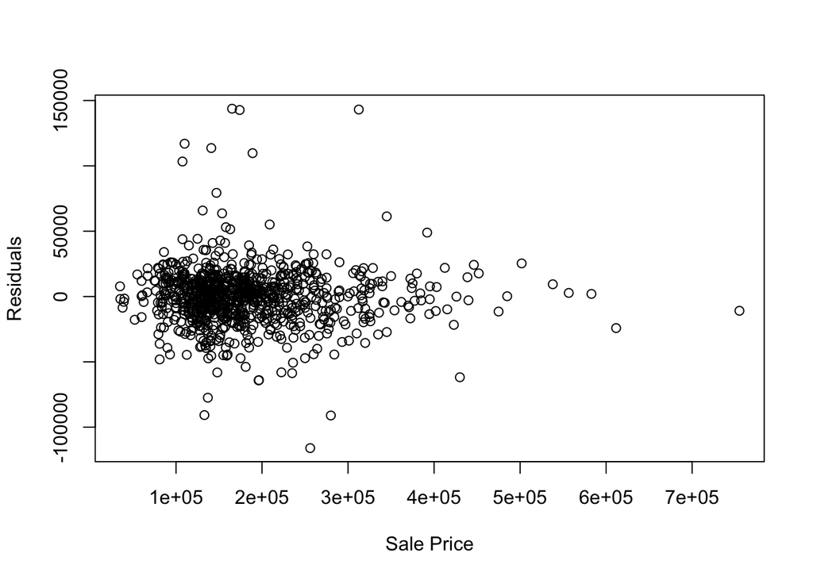

```r
plot(SalePrice[train_samp1],resid(full_fit),xlab="Sale Price",ylab="Residuals")
```

Finally, we find the error of the testing data.

```r
full_pred = predict(full_fit,train_final[-train_samp1,],interval = "none")

error1 = sqrt(sum(full_pred-train_final[-train_samp1,]$SalePrice)^2)
error1
```

```
## [1] 926598.1
```